# Spatial Analysis in R

05/11, 2020

## What is GIS

## Geographic Information System

- Spatial representation of data
- Many type of data
  - Remote sensing data (Spectral data, lidar)
  - Modelled datasets (Species distribution models)
  - Expert data (Estimated distribution)
  - Future planning (Systematic conservation planning)
  - Fantasy maps (Middle-earth, Westeros)
- Two main formats
  - Vectorial data (Shapefiles)
  - Grid data (Rasters)

## Vectorial datasets

- Shapefiles (*.shp*)
- **Points** Example `Abundance.csv` (Cities, species presences, events, sampling sites)
- Lines (Rivers, Roads, Paths)
- **Polygons** example `Africa.shp` (Countries, regions, provinces, lakes)
- Packages (sf, sp)

## Polygons

## Vectorial data example

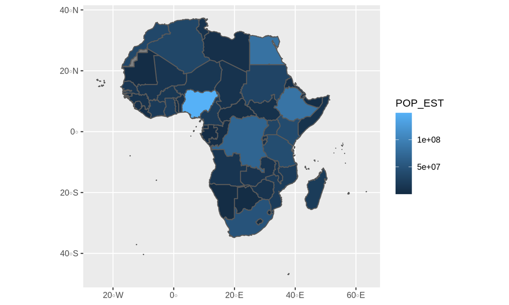

```r
library(sf)
library(tidyverse)
Africa <- read_sf("Africa.shp")
ggplot() + geom_sf(data = Africa, aes(fill = POP_EST))
```

## Example vectorial data (cont.)

```r
ggplot() + geom_sf(data = Africa, aes(fill = GEO3))
```

## Points example

## Read from csv

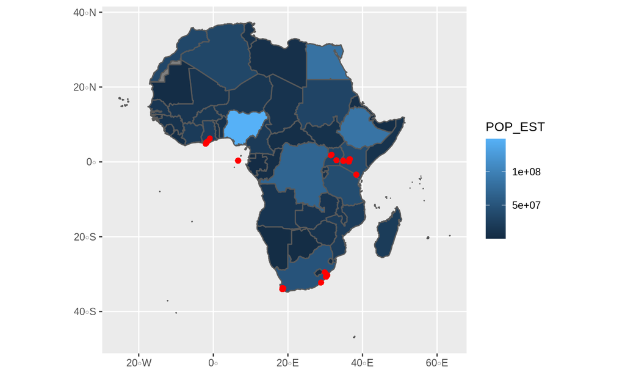

```r
Abundance <- read_csv("Abundance.csv")
Abundance_sf <- Abundance %>% st_as_sf(coords = c(9, 10), crs = "+proj=longlat +ellps=WGS84 +datum=WGS84 +no_defs +towgs84=0,0,0")
ggplot() + geom_sf(data = Africa, aes(fill = POP_EST)) + geom_sf(data = Abundance_sf,
    color = "red")
```

## Plot points using another variable

```r
ggplot() + geom_sf(data = Africa, aes(fill = POP_EST)) + geom_sf(data = Abundance_sf,
    aes(color = Family))
```

## Plot points using another variable

```r
ggplot() + geom_sf(data = Africa, aes(fill = POP_EST)) + geom_sf(data = Abundance_sf,
    aes(size = Measurement))
```

## Grid Data

## Grid data

- Similar to a picture
- Each pixel has certain characteristics (resolution, projection, units)
- Example `Clim.tif`

## Read mean temperature and precipitation

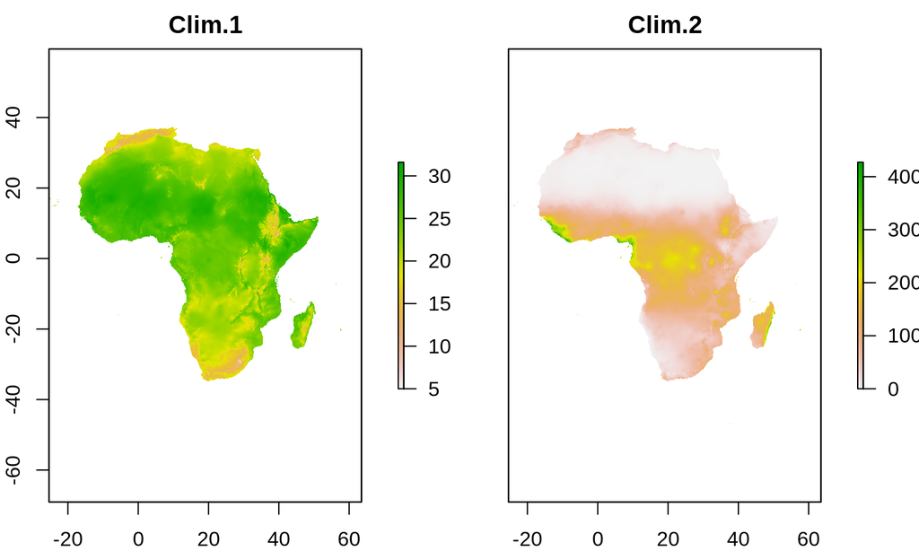

```r
Clim <- stack("Clim.tif")
plot(Clim)
```

## Change names

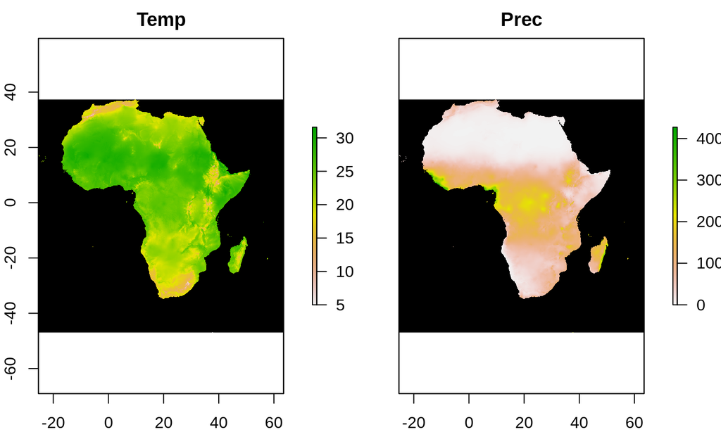

```r
names(Clim) <- c("Temp", "Prec")
plot(Clim, colNA = "black")
```

## Summary

## To read

```r
DF <- tibble(Action = c("Read"), Shapefile = c("read_sf"), CSV = c("read_csv"),
    Raster = c("stack/raster"))
kable(DF) %>% kable_styling(bootstrap_options = c("striped",
    "hover"))
```

| Action | Shapefile | CSV | Raster |
| --- | --- | --- | --- |
| Read | read_sf | read_csv | stack/raster |

## Plot together

## Transform raster to DF

```r
Clim_DF <- Clim %>% as("SpatialPixelsDataFrame") %>% as.data.frame()
head(Clim_DF)
```

```
##   Temp Prec        x       y
## 1 17.5  613 9.645833 37.3125
## 2 17.5  601 9.687500 37.3125
## 3 17.4  600 9.729167 37.3125
## 4 17.6  577 9.770833 37.3125
## 5 17.6  562 9.812500 37.3125
## 6 17.6  550 9.854167 37.3125
```

## Plot together

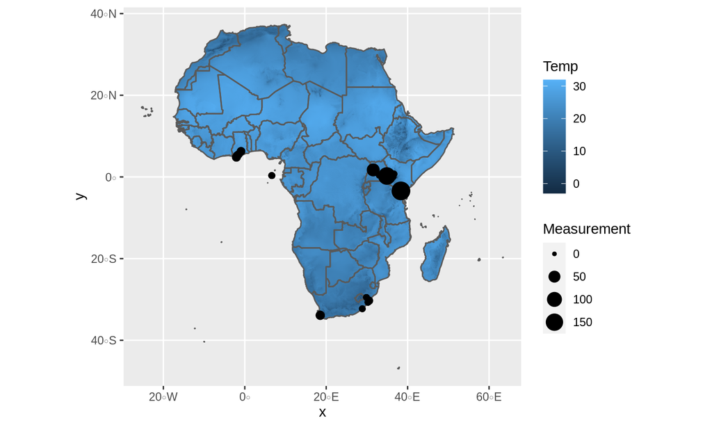

```r
ggplot() + geom_raster(data = Clim_DF, aes(x = x, y = y, fill = Temp)) +
    geom_sf(data = Africa, alpha = 0) + geom_sf(data = Abundance_sf,
    aes(size = Measurement))
```

## Improve scale

```r
ggplot() + geom_raster(data = Clim_DF, aes(x = x, y = y, fill = Temp)) +
    geom_sf(data = Africa, alpha = 0) + geom_sf(data = Abundance_sf,
    aes(size = Measurement)) + scale_fill_viridis_c(name = "Temperature")
```

## White background

```r
ggplot() + geom_raster(data = Clim_DF, aes(x = x, y = y, fill = Temp)) +
    geom_sf(data = Africa, alpha = 0) + geom_sf(data = Abundance_sf,
    aes(size = Measurement)) + scale_fill_viridis_c(name = "Temperature") +
    theme_bw()
```

## Remove axis names

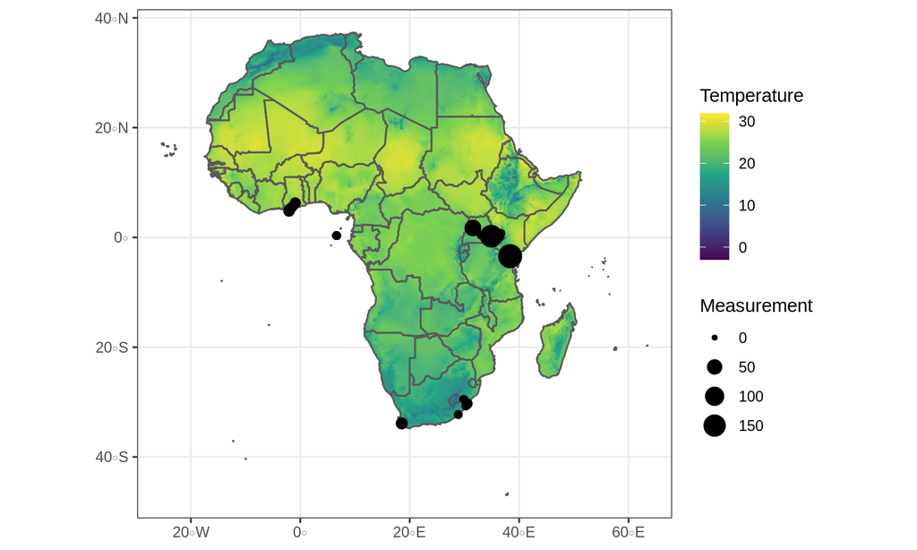

```r
ggplot() + geom_raster(data = Clim_DF, aes(x = x, y = y, fill = Temp)) +
    geom_sf(data = Africa, alpha = 0) + geom_sf(data = Abundance_sf,
    aes(size = Measurement)) + scale_fill_viridis_c(name = "Temperature") +
    theme_bw() + labs(y = NULL, x = NULL)
```

## Sub setting and cropping

## Sub setting Vectorial data

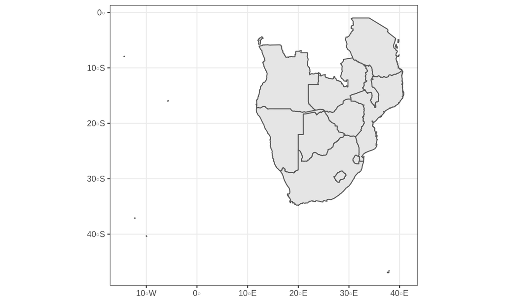

```r
Southern <- Africa %>% dplyr::filter(GEO3 == "Southern Africa")
ggplot() + geom_sf(data = Southern) + theme_bw()
```

## Sub setting Vectorial data

```r
SouthCentral <- Africa %>% dplyr::filter(GEO3 %in% c("Southern Africa",
    "Central Africa"))
```

## Sub setting using numeric variables

```r
MedianGDP <- median(Africa$GDP_MD_)
Richest <- Africa %>% dplyr::filter(GDP_MD_ > MedianGDP)
```

## Cropping raster data

## Lets say we just want to see climate from Namibia

- First we create a polygon of Namibia

```r
Namibia <- Africa %>% dplyr::filter(SOVEREI == "Namibia")
```

- Then crop climate to that

```r
Clim_Namibia <- Clim %>% crop(Namibia)
```

## Modify datasets

## Create vectorial variables with mutate

- Lets generate GDP_Per_Capita
- We will divide `GDP_MD_` by `POP_EST` with mutate

```r
Africa <- Africa %>% mutate(GDP_Per_Capita = GDP_MD_/POP_EST)
```

- Now we can see that new variable

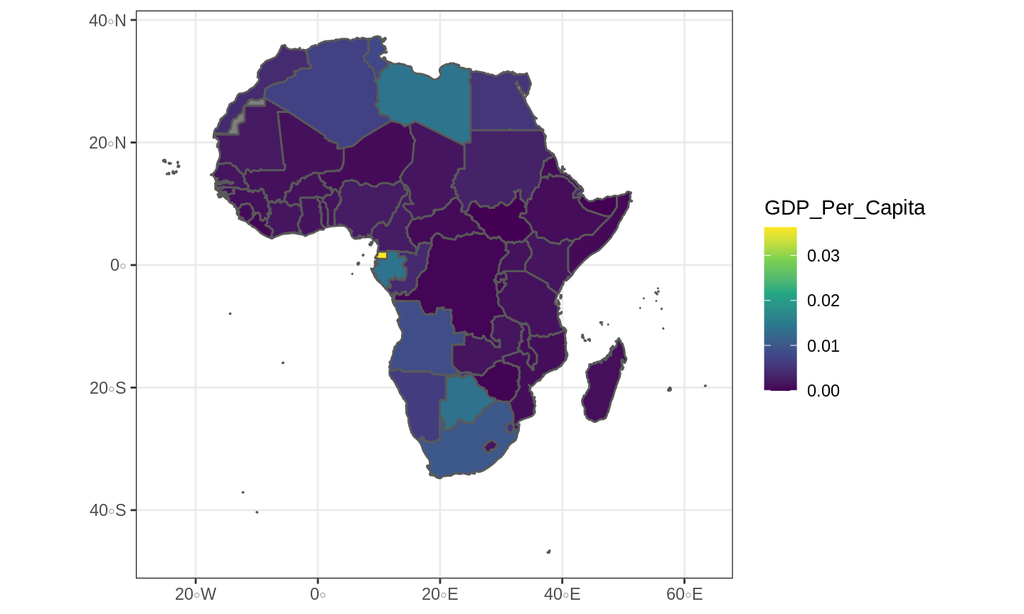

```r
ggplot() + geom_sf(data = Africa, aes(fill = GDP_Per_Capita)) +
    scale_fill_viridis_c() + theme_bw()
```

## Create Grid variables

- Temperature in Fahrenheit

```r
Fahrenheit <- (Clim[[1]] * (9/5)) + 32
```

## Export your data

## Export your data

- For vectorial data

```r
write_sf(Namibia, "Namibia.shp")
```

- For raster data

```r
writeRaster(Fahrenheit, "Temp_F.tif", format = "GTiff", overwrite = TRUE)
```

- **Formats:** .grd, .asc, .sdat, .rst, .nc, .tif, .envi, .bil, .img

## Summary

## To write

```r
DF <- tibble(Action = c("Read", "Write"), Shapefile = c("read_sf",
    "write_sf"), CSV = c("read_csv", "write_sf"), Raster = c("stack/raster",
    "writeRaster"))
kable(DF) %>% kable_styling(bootstrap_options = c("striped",
    "hover"))
```

| Action | Shapefile | CSV | Raster |
| --- | --- | --- | --- |
| Read | read_sf | read_csv | stack/raster |
| Write | write_sf | write_sf | writeRaster |

## Resources

## Resources

- [SF](https://r-spatial.github.io/sf/)
- [raster](https://rspatial.org/raster/)
- [Example interactive map using leaflet](https://rpubs.com/derek_corcoran/Mapa_El_Soldado)
- [Interactive maps](https://rstudio.github.io/leaflet/)
- [Spatial Data Science book](https://keen-swartz-3146c4.netlify.app/)
- [Example of webapp in r using shiny](https://www.ecoinformatica.net/GCMcompareR.html)

## If we get the chance

## Model abundance

- Model abundance of Heuglin’s white-eye (*Zosterops poliogaster*)

```r
ForModel <- Abundance_sf %>% dplyr::filter(Best_guess_binomial ==
    "Zosterops poliogaster")
Area <- Clim %>% crop(ForModel)
```

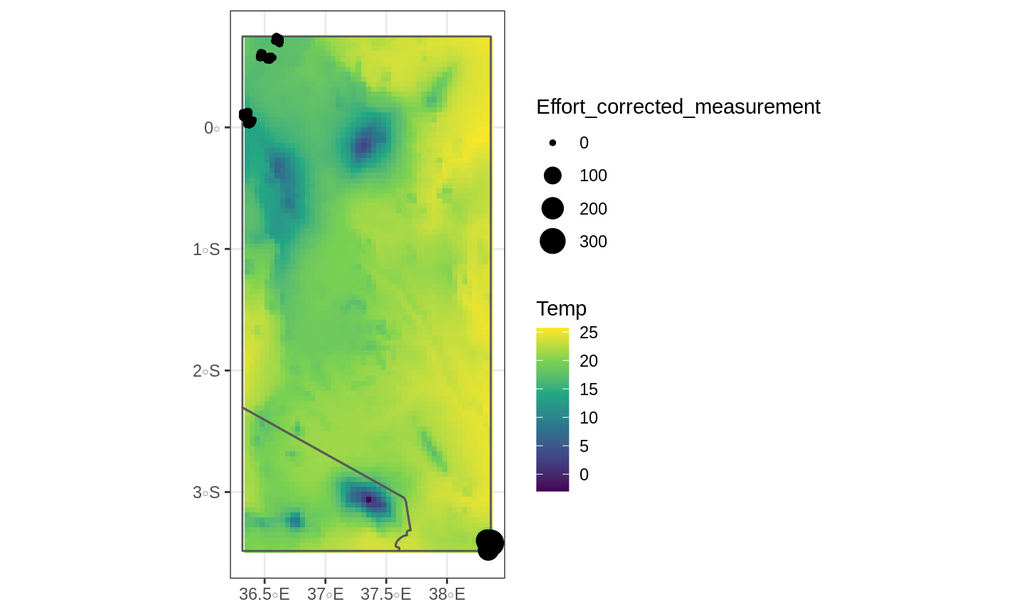

## Prediction

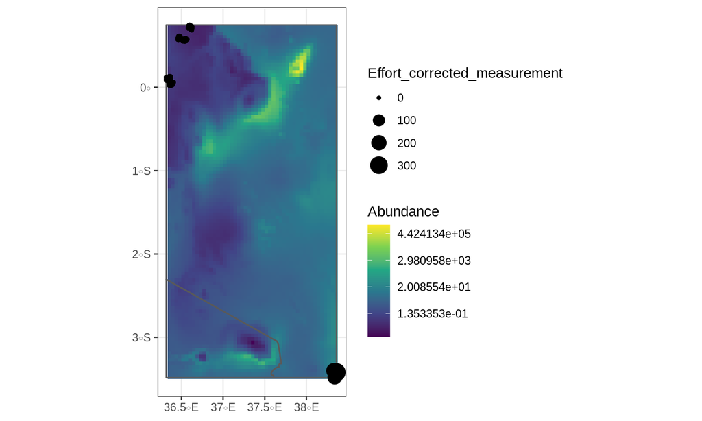